# Regional association plotting of 11 loci associated with CAC.

### All loci

Let’s do some plotting.

```r
library(RACER)
# Make directory for plots
ifelse(!dir.exists(file.path(PROJECT_loc, "/RACER")),
       dir.create(file.path(PROJECT_loc, "/RACER")),
       FALSE)
```

```
[1] FALSE
```

```
Getting data for rs9349379.

Subset required data.

Formatting association data.
```

```
Formating association data...
Processing -log10(p-values)...
Preparing association data...
```

```
Getting LD data.
```

```
All inputs are go!
Reading in association data...
Populations selected.
Calculating LD using rs9349379...
```

```
[1] "https://ldlink.nci.nih.gov/LDlinkRest/ldproxy?var=rs9349379&pop=EUR&r2_d=r2&token=c0f613f149ab"
```

```
 [22%] Downloaded 15980 bytes...
 [45%] Downloaded 32210 bytes...
 [69%] Downloaded 49152 bytes...
 [92%] Downloaded 65518 bytes...
 [100%] Downloaded 70967 bytes...
Merging input association data with LD...
```

```
Plotting region surrounding rs9349379 on 6:12403957-13403957.
```

```
Plotting by...
snp rs9349379
Reading in association data
Determining lead SNP
Generating Plot
```

```
Saving image for rs9349379.
Getting data for rs3844006.

Subset required data.

Formatting association data.
```

```
Formating association data...
Processing -log10(p-values)...
Preparing association data...
```

```
Getting LD data.
```

```
All inputs are go!
Reading in association data...
Populations selected.
Calculating LD using rs3844006...
```

```
[1] "https://ldlink.nci.nih.gov/LDlinkRest/ldproxy?var=rs3844006&pop=EUR&r2_d=r2&token=c0f613f149ab"
```

```
 [51%] Downloaded 15980 bytes...
 [100%] Downloaded 31016 bytes...
Merging input association data with LD...
```

```
Plotting region surrounding rs3844006 on 6:131595002-132595002.
```

```
Plotting by...
snp rs3844006
Reading in association data
Determining lead SNP
Generating Plot
```

```
Saving image for rs3844006.
Getting data for rs2854746.

Subset required data.

Formatting association data.
```

```
Formating association data...
Processing -log10(p-values)...
Preparing association data...
```

```
Getting LD data.
```

```
All inputs are go!
Reading in association data...
Populations selected.
Calculating LD using rs2854746...
```

```
[1] "https://ldlink.nci.nih.gov/LDlinkRest/ldproxy?var=rs2854746&pop=EUR&r2_d=r2&token=c0f613f149ab"
```

```
 [14%] Downloaded 15979 bytes...
 [29%] Downloaded 32209 bytes...
 [44%] Downloaded 48575 bytes...
 [52%] Downloaded 57344 bytes...
 [67%] Downloaded 73710 bytes...
 [82%] Downloaded 90112 bytes...
 [100%] Downloaded 109298 bytes...
Merging input association data with LD...
```

```
Plotting region surrounding rs2854746 on 7:45460645-46460645.
```

```
Plotting by...
snp rs2854746
Reading in association data
Determining lead SNP
Generating Plot
```

```
Saving image for rs2854746.
Getting data for rs4977575.

Subset required data.

Formatting association data.
```

```
Formating association data...
Processing -log10(p-values)...
Preparing association data...
```

```
Getting LD data.
```

```
All inputs are go!
Reading in association data...
Populations selected.
Calculating LD using rs4977575...
```

```
[1] "https://ldlink.nci.nih.gov/LDlinkRest/ldproxy?var=rs4977575&pop=EUR&r2_d=r2&token=c0f613f149ab"
```

```
 [61%] Downloaded 15980 bytes...
 [100%] Downloaded 26000 bytes...
Merging input association data with LD...
```

```
Plotting region surrounding rs4977575 on 9:21624744-22624744.
```

```
Plotting by...
snp rs4977575
Reading in association data
Determining lead SNP
Generating Plot
```

```
Saving image for rs4977575.
Getting data for rs10899970.

Subset required data.

Formatting association data.
```

```
Formating association data...
Processing -log10(p-values)...
Preparing association data...
```

```
Getting LD data.
```

```
All inputs are go!
Reading in association data...
Populations selected.
Calculating LD using rs10899970...
```

```
[1] "https://ldlink.nci.nih.gov/LDlinkRest/ldproxy?var=rs10899970&pop=EUR&r2_d=r2&token=c0f613f149ab"
```

```
 [4%] Downloaded 7633 bytes...
 [14%] Downloaded 23495 bytes...
 [20%] Downloaded 32768 bytes...
 [24%] Downloaded 39495 bytes...
 [30%] Downloaded 49152 bytes...
 [34%] Downloaded 55495 bytes...
 [44%] Downloaded 71495 bytes...
 [51%] Downloaded 81920 bytes...
 [54%] Downloaded 87843 bytes...
 [64%] Downloaded 104209 bytes...
 [71%] Downloaded 114688 bytes...
 [81%] Downloaded 131054 bytes...
 [91%] Downloaded 147456 bytes...
 [100%] Downloaded 160476 bytes...
Merging input association data with LD...
```

```
Plotting region surrounding rs10899970 on 10:44015716-45334720.
```

```
Plotting by...
snp rs10899970
Reading in association data
Determining lead SNP
Generating Plot
```

```
Saving image for rs10899970.
Getting data for rs9633535.

Subset required data.

Formatting association data.
```

```
Formating association data...
Processing -log10(p-values)...
Preparing association data...
```

```
Getting LD data.
```

```
All inputs are go!
Reading in association data...
Populations selected.
Calculating LD using rs9633535...
```

```
[1] "https://ldlink.nci.nih.gov/LDlinkRest/ldproxy?var=rs9633535&pop=EUR&r2_d=r2&token=c0f613f149ab"
```

```
 [65%] Downloaded 32210 bytes...
 [100%] Downloaded 49363 bytes...
Merging input association data with LD...
```

```
Plotting region surrounding rs9633535 on 10:63336088-64336088.
```

```
Plotting by...
snp rs9633535
Reading in association data
Determining lead SNP
Generating Plot
```

```
Saving image for rs9633535.
Getting data for rs10762577.

Subset required data.

Formatting association data.
```

```
Formating association data...
Processing -log10(p-values)...
Preparing association data...
```

```
Getting LD data.
```

```
All inputs are go!
Reading in association data...
Populations selected.
Calculating LD using rs10762577...
```

```
[1] "https://ldlink.nci.nih.gov/LDlinkRest/ldproxy?var=rs10762577&pop=EUR&r2_d=r2&token=c0f613f149ab"
```

```
 [17%] Downloaded 15980 bytes...
 [77%] Downloaded 71862 bytes...
 [94%] Downloaded 88264 bytes...
 [100%] Downloaded 92997 bytes...
Merging input association data with LD...
```

```
Plotting region surrounding rs10762577 on 10:75417431-76417431.
```

```
Plotting by...
snp rs10762577
Reading in association data
Determining lead SNP
Generating Plot
```

```
Saving image for rs10762577.
Getting data for rs11063120.

Subset required data.

Formatting association data.
```

```
Formating association data...
Processing -log10(p-values)...
Preparing association data...
```

```
Getting LD data.
```

```
All inputs are go!
Reading in association data...
Populations selected.
Calculating LD using rs11063120...
```

```
[1] "https://ldlink.nci.nih.gov/LDlinkRest/ldproxy?var=rs11063120&pop=EUR&r2_d=r2&token=c0f613f149ab"
```

```
 [38%] Downloaded 15980 bytes...
 [76%] Downloaded 32210 bytes...
 [100%] Downloaded 41883 bytes...
Merging input association data with LD...
```

```
Plotting region surrounding rs11063120 on 12:3986618-4986618.
```

```
Plotting by...
snp rs11063120
Reading in association data
Determining lead SNP
Generating Plot
```

```
Saving image for rs11063120.
Getting data for rs9515203.

Subset required data.

Formatting association data.
```

```
Formating association data...
Processing -log10(p-values)...
Preparing association data...
```

```
Getting LD data.
```

```
All inputs are go!
Reading in association data...
Populations selected.
Calculating LD using rs9515203...
```

```
[1] "https://ldlink.nci.nih.gov/LDlinkRest/ldproxy?var=rs9515203&pop=EUR&r2_d=r2&token=c0f613f149ab"
```

```
 [53%] Downloaded 15980 bytes...
 [100%] Downloaded 30139 bytes...
Merging input association data with LD...
```

```
Plotting region surrounding rs9515203 on 13:110549623-111549623.
```

```
Plotting by...
snp rs9515203
Reading in association data
Determining lead SNP
Generating Plot
```

```
Saving image for rs9515203.
Getting data for rs7182103.

Subset required data.

Formatting association data.
```

```
Formating association data...
Processing -log10(p-values)...
Preparing association data...
```

```
Getting LD data.
```

```
All inputs are go!
Reading in association data...
Populations selected.
Calculating LD using rs7182103...
```

```
[1] "https://ldlink.nci.nih.gov/LDlinkRest/ldproxy?var=rs7182103&pop=EUR&r2_d=r2&token=c0f613f149ab"
```

```
 [13%] Downloaded 15979 bytes...
 [27%] Downloaded 32209 bytes...
 [41%] Downloaded 48575 bytes...
 [41%] Downloaded 49152 bytes...
 [55%] Downloaded 65518 bytes...
 [69%] Downloaded 81920 bytes...
 [83%] Downloaded 98286 bytes...
 [96%] Downloaded 114688 bytes...
 [100%] Downloaded 118299 bytes...
Merging input association data with LD...
```

```
Plotting region surrounding rs7182103 on 15:78623946-79623946.
```

```
Plotting by...
snp rs7182103
Reading in association data
Determining lead SNP
Generating Plot
```

```
Saving image for rs7182103.
Getting data for rs7412.

Subset required data.

Formatting association data.
```

```
Formating association data...
Processing -log10(p-values)...
Preparing association data...
```

```
Getting LD data.
```

```
All inputs are go!
Reading in association data...
Populations selected.
Calculating LD using rs7412...
```

```
[1] "https://ldlink.nci.nih.gov/LDlinkRest/ldproxy?var=rs7412&pop=EUR&r2_d=r2&token=c0f613f149ab"
```

```
 [41%] Downloaded 15980 bytes...
 [82%] Downloaded 32210 bytes...
 [100%] Downloaded 38865 bytes...
Merging input association data with LD...
```

```
Plotting region surrounding rs7412 on 19:44912079-45912079.
```

```
Plotting by...
snp rs7412
Reading in association data
Determining lead SNP
Generating Plot
```

```
Saving image for rs7412.
```

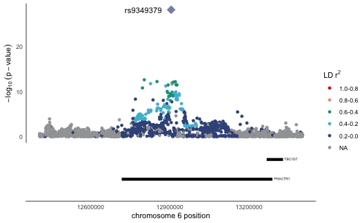

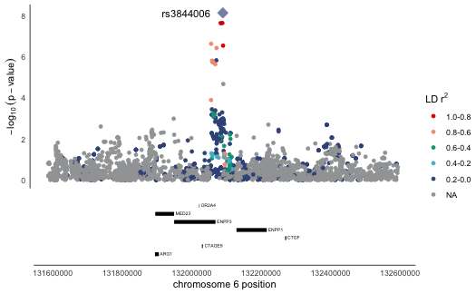

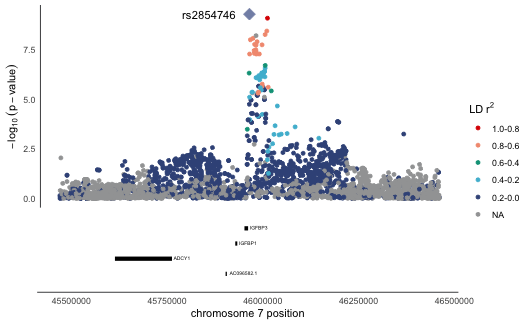

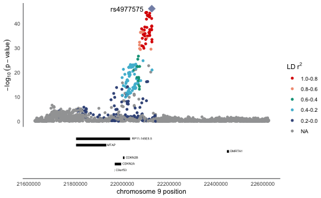

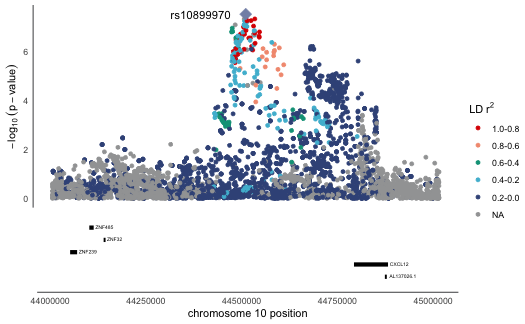

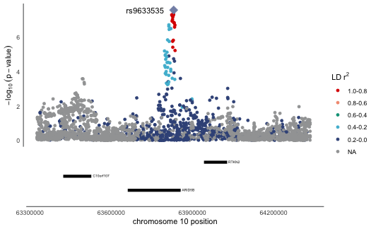

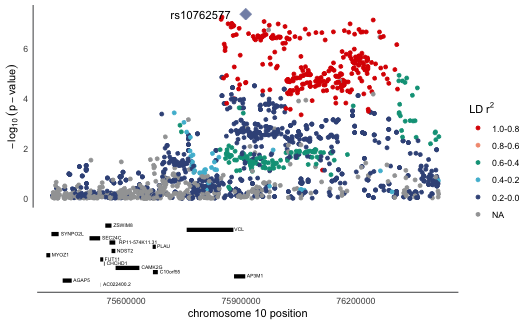

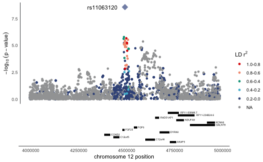

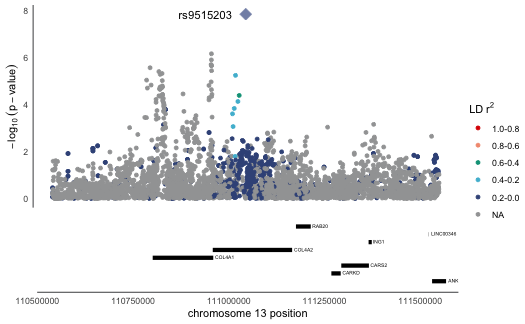

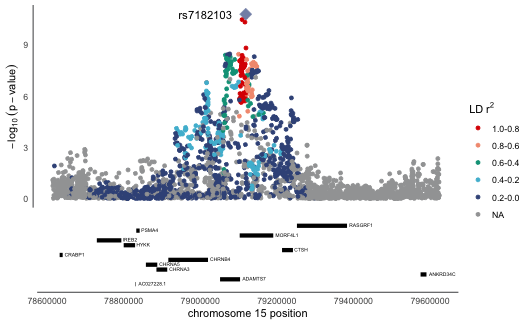

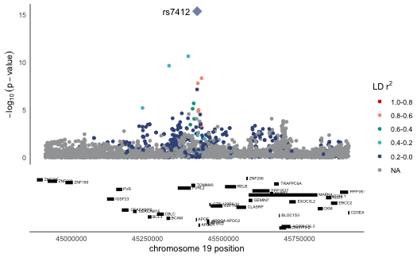

```r
RACER_loc = paste0(PROJECT_loc,"/RACER")

variants_of_interest <- c(variant_list$rsID)

variants_of_interest_fewgenes <- c("rs9349379")#, "rs3844006", "rs2854746", "rs4977575", "rs9633535", "rs11063120", "rs9515203", "rs7182103")

for(VARIANT in variants_of_interest){
  cat(paste0("Getting data for ", VARIANT,".\n"))

  tempCHR <- subset(variant_list, rsID == VARIANT)[,5]
  tempSTART <- subset(variant_list, rsID == VARIANT)[,17]
  tempEND <- subset(variant_list, rsID == VARIANT)[,18]
  tempVARIANTnr <- subset(variant_list, rsID == VARIANT)[,1]

  cat("\nSubset required data.\n")
  temp <- subset(gwas_sumstats_racer_EA_AA, Chr == tempCHR & (Position >= tempSTART & Position <= tempEND))

  cat("\nFormatting association data.\n")
  temp_f = RACER::formatRACER(assoc_data = temp, chr_col = 3, pos_col = 4, p_col = 5)

  cat("\nGetting LD data.\n")
  temp_f_ld = RACER::ldRACER(assoc_data = temp_f, rs_col = 2, pops = "EUR", lead_snp = VARIANT)

  cat(paste0("\nPlotting region surrounding ", VARIANT," on ",tempCHR,":",tempSTART,"-",tempEND,".\n"))
  p1 <- singlePlotRACER2(assoc_data = temp_f_ld,
                               chr = tempCHR, build = "hg19",
                               plotby = "snp", snp_plot = VARIANT,
                               label_lead = TRUE, gene_track_h = 2, gene_name_s = 1.75)

  print(p1)
  cat(paste0("Saving image for ", VARIANT,".\n"))
  # ggsave(filename = paste0(RACER_loc, "/", tempVARIANTnr, ".", Today, ".",VARIANT,".regional_assoc.png"), plot = last_plot())
  # ggsave(filename = paste0(RACER_loc, "/", tempVARIANTnr, ".", Today, ".",VARIANT,".regional_assoc.pdf"), plot = last_plot())
  # ggsave(filename = paste0(RACER_loc, "/", tempVARIANTnr, ".", Today, ".",VARIANT,".regional_assoc.eps"), plot = last_plot())

  # rm(temp, p1,
  #    temp_f, temp_f_ld,
  #    tempCHR, tempSTART, tempEND,
  #    VARIANT, tempVARIANTnr)

}
```

### Loci with many genes

These are genetic loci with many genes.

```
Getting data for rs7412.

Subset required data.

Formatting association data.
```

```
Formating association data...
Processing -log10(p-values)...
Preparing association data...
```

```
Getting LD data.
```

```
All inputs are go!
Reading in association data...
Populations selected.
Calculating LD using rs7412...
```

```
[1] "https://ldlink.nci.nih.gov/LDlinkRest/ldproxy?var=rs7412&pop=EUR&r2_d=r2&token=c0f613f149ab"
```

```
 [41%] Downloaded 15980 bytes...
 [82%] Downloaded 32210 bytes...
 [100%] Downloaded 38865 bytes...
Merging input association data with LD...
```

```
Plotting region surrounding rs7412 on 19:44912079-45912079.
```

```
Plotting by...
snp rs7412
Reading in association data
Determining lead SNP
Generating Plot
```

```
Saving image for rs7412.
Getting data for rs10762577.

Subset required data.

Formatting association data.
```

```
Formating association data...
Processing -log10(p-values)...
Preparing association data...
```

```
Getting LD data.
```

```
All inputs are go!
Reading in association data...
Populations selected.
Calculating LD using rs10762577...
```

```
[1] "https://ldlink.nci.nih.gov/LDlinkRest/ldproxy?var=rs10762577&pop=EUR&r2_d=r2&token=c0f613f149ab"
```

```
 [17%] Downloaded 15980 bytes...
 [34%] Downloaded 32210 bytes...
 [52%] Downloaded 49152 bytes...
 [70%] Downloaded 65518 bytes...
 [88%] Downloaded 81920 bytes...
 [100%] Downloaded 92997 bytes...
Merging input association data with LD...
```

```
Plotting region surrounding rs10762577 on 10:75417431-76417431.
```

```
Plotting by...
snp rs10762577
Reading in association data
Determining lead SNP
Generating Plot
```

```
Saving image for rs10762577.
```

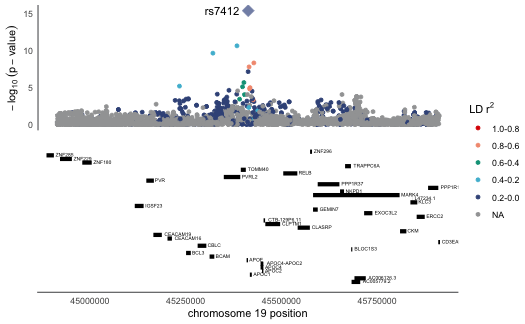

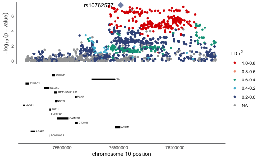

```r
variants_of_interest_manygenes <- c("rs7412", "rs10762577")

for(VARIANT in variants_of_interest_manygenes){
  cat(paste0("Getting data for ", VARIANT,".\n"))

  tempCHR <- subset(variant_list, rsID == VARIANT)[,5]
  tempSTART <- subset(variant_list, rsID == VARIANT)[,17]
  tempEND <- subset(variant_list, rsID == VARIANT)[,18]
  tempVARIANTnr <- subset(variant_list, rsID == VARIANT)[,1]

  cat("\nSubset required data.\n")
  temp <- subset(gwas_sumstats_racer_EA_AA, Chr == tempCHR & (Position >= tempSTART & Position <= tempEND))

  cat("\nFormatting association data.\n")
  temp_f = RACER::formatRACER(assoc_data = temp, chr_col = 3, pos_col = 4, p_col = 5)

  cat("\nGetting LD data.\n")
  temp_f_ld = RACER::ldRACER(assoc_data = temp_f, rs_col = 2, pops = "EUR", lead_snp = VARIANT)

  cat(paste0("\nPlotting region surrounding ", VARIANT," on ",tempCHR,":",tempSTART,"-",tempEND,".\n"))
  p1 <- singlePlotRACER2(assoc_data = temp_f_ld,
                               chr = tempCHR, build = "hg19",
                               plotby = "snp", snp_plot = VARIANT,
                               label_lead = TRUE, gene_track_h = 0.75, gene_name_s = 1.75)

  print(p1)
  cat(paste0("Saving image for ", VARIANT,".\n"))
  # ggsave(filename = paste0(RACER_loc, "/", tempVARIANTnr, ".", Today, ".",VARIANT,".regional_assoc.png"), plot = last_plot())
  # ggsave(filename = paste0(RACER_loc, "/", tempVARIANTnr, ".", Today, ".",VARIANT,".regional_assoc.pdf"), plot = last_plot())
  # ggsave(filename = paste0(RACER_loc, "/", tempVARIANTnr, ".", Today, ".",VARIANT,".regional_assoc.eps"), plot = last_plot())

  rm(temp, p1,
     temp_f, temp_f_ld,
     tempCHR, tempSTART, tempEND,
     VARIANT, tempVARIANTnr)

}
```

### CXCL12

The *CXCL12* genetic locus.

```
Getting data for rs10899970.

Subset required data.

Formatting association data.
```

```
Formating association data...
Processing -log10(p-values)...
Preparing association data...
```

```
Getting LD data.
```

```
All inputs are go!
Reading in association data...
Populations selected.
Calculating LD using rs10899970...
```

```
[1] "https://ldlink.nci.nih.gov/LDlinkRest/ldproxy?var=rs10899970&pop=EUR&r2_d=r2&token=c0f613f149ab"
```

```
 [9%] Downloaded 15979 bytes...
 [20%] Downloaded 32209 bytes...
 [30%] Downloaded 48575 bytes...
 [40%] Downloaded 64977 bytes...
 [50%] Downloaded 81343 bytes...
 [60%] Downloaded 97709 bytes...
 [60%] Downloaded 97745 bytes...
 [71%] Downloaded 114111 bytes...
 [81%] Downloaded 130513 bytes...
 [91%] Downloaded 146879 bytes...
 [100%] Downloaded 160476 bytes...
Merging input association data with LD...
```

```
Plotting region surrounding rs10899970 on 10:44015716-45334720.
```

```
Plotting by...
snp rs10899970
Reading in association data
Determining lead SNP
Generating Plot
```

```
Saving image for rs10899970.
```

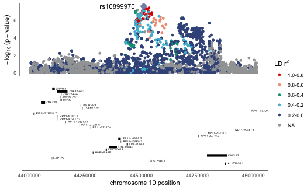

```r
variants_of_interest_cxcl12 <- c("rs10899970")

for(VARIANT in variants_of_interest_cxcl12){
  cat(paste0("Getting data for ", VARIANT,".\n"))

  tempCHR <- subset(variant_list, rsID == VARIANT)[,5]
  tempSTART <- subset(variant_list, rsID == VARIANT)[,17]
  tempEND <- subset(variant_list, rsID == VARIANT)[,18]
  tempVARIANTnr <- subset(variant_list, rsID == VARIANT)[,1]

  cat("\nSubset required data.\n")
  temp <- subset(gwas_sumstats_racer_EA_AA, Chr == tempCHR & (Position >= tempSTART & Position <= tempEND))

  cat("\nFormatting association data.\n")
  temp_f = RACER::formatRACER(assoc_data = temp, chr_col = 3, pos_col = 4, p_col = 5)

  cat("\nGetting LD data.\n")
  temp_f_ld = RACER::ldRACER(assoc_data = temp_f, rs_col = 2, pops = "EUR", lead_snp = VARIANT)

  cat(paste0("\nPlotting region surrounding ", VARIANT," on ",tempCHR,":",tempSTART,"-",tempEND,".\n"))
  p1 <- singlePlotRACER2(assoc_data = temp_f_ld,
                               chr = tempCHR, build = "hg19", set = "all",
                               plotby = "snp", snp_plot = VARIANT,
                               label_lead = TRUE, gene_track_h = 0.75, gene_name_s = 1.75)

  print(p1)
  cat(paste0("Saving image for ", VARIANT,".\n"))
  # ggsave(filename = paste0(RACER_loc, "/", tempVARIANTnr, ".", Today, ".",VARIANT,".regional_assoc.png"), plot = last_plot())
  # ggsave(filename = paste0(RACER_loc, "/", tempVARIANTnr, ".", Today, ".",VARIANT,".regional_assoc.pdf"), plot = last_plot())
  # ggsave(filename = paste0(RACER_loc, "/", tempVARIANTnr, ".", Today, ".",VARIANT,".regional_assoc.eps"), plot = last_plot())

  rm(temp, p1,
     temp_f, temp_f_ld,
     tempCHR, tempSTART, tempEND,
     VARIANT, tempVARIANTnr)

}
```

## Additional regional plots

### Listing regions of interest

We want to create some regional association plots to combine with teh UCSC browser tracks, thus we need the exact same regions.

```r
library(openxlsx)
add_list <- read.xlsx(paste0(TARGET_loc, "/Variants.xlsx"), sheet = "AdditionalPlots")

DT::datatable(add_list)
```

|  | rsID | uniqID | GeneSymbols | chr | start_region | end_region |
| --- | --- | --- | --- | --- | --- | --- |
| 1 | rs9633535 | chr10:63584853-63921073 | ARID5B | 10 | 63584853 | 63921073 |
| 2 | rs2854746 | chr7:45894617-46054070 | IGFBP3 | 7 | 45894617 | 46054070 |
| 3 | rs3844006 | chr6:131937915-132289374 | ENNP1-ENNP3 | 6 | 131937915 | 132289374 |

```r
NA
```

### Credible Sets

We want to color the credible sets, which we load here.

```r
credset <- as_tibble(fread(paste0(PROJECT_loc, "/CredibleSets/CAC_EUR_AFR_cred_set_all_loci_50kb.txt")))

credset
```

| column_label | CHR | POS | RSID | A1 | A0 | Zscore | P | Posterior_Prob |
| --- | --- | --- | --- | --- | --- | --- | --- | --- |
| rs10762577_locus_all | 10 | 75917431 | rs10762577 | a | g | -5.48969 | 4.094e-08 | 0.524 |
| rs10762577_locus_all | 10 | 75900462 | rs7896966 | a | c | 5.24742 | 1.506e-07 | 0.148 |
| rs10762577_locus_all | 10 | 75924605 | rs7894143 | c | g | 5.16842 | 2.465e-07 | 0.092 |
| rs10762577_locus_all | 10 | 75892904 | rs7919821 | a | g | -5.14660 | 2.693e-07 | 0.085 |
| rs10762577_locus_all | 10 | 75936611 | rs10824095 | t | c | 5.11340 | 3.186e-07 | 0.072 |
| rs10762577_locus_all | 10 | 75939921 | rs10733895 | t | c | 5.07895 | 3.987e-07 | 0.058 |
| rs10899970_locus_all | 10 | 44515716 | rs10899970 | a | g | 5.55882 | 2.914e-08 | 0.061 |
| rs10899970_locus_all | 10 | 44513936 | rs1352999 | a | g | -5.48235 | 4.455e-08 | 0.041 |
| rs10899970_locus_all | 10 | 44539016 | rs1873757 | a | g | 5.48235 | 4.534e-08 | 0.040 |
| rs10899970_locus_all | 10 | 44516604 | rs10899971 | t | c | 5.47647 | 4.582e-08 | 0.040 |

[output cut: 93 more lines]

### Combining GWAS with Credible Set

We want to add the posterior probabilities and make a variable to color by.

```r
gwas_sumstats_racer_credset <- merge(gwas_sumstats_racer_EA_AA,
                                     credset %>% select(RSID, Posterior_Prob),
                                     sort = FALSE,
                                     by.x = "rsID", by.y = "RSID", all.x = TRUE) %>%
  # mutate(., Posterior_Prob = ifelse(is.na(Posterior_Prob), 0, Posterior_Prob)) %>%
  mutate(CredSet = case_when(Posterior_Prob > 0 ~ '95% credible set',
                             TRUE ~ 'not in credible set'))

head(gwas_sumstats_racer_credset)
```

| rsID | MarkerName | Chr | Position | Pvalue | Posterior_Prob | CredSet |
| --- | --- | --- | --- | --- | --- | --- |
| rs61769339 | 1:662622 | 1 | 662622 | 0.1628 | NA | not in credible set |
| rs61769350 | 1:693731 | 1 | 693731 | 0.5851 | NA | not in credible set |
| . | 1:697411:ID | 1 | 697411 | 0.8763 | NA | not in credible set |
| rs189800799 | 1:701835 | 1 | 701835 | 0.5042 | NA | not in credible set |
| rs55727773 | 1:706368 | 1 | 706368 | 0.1025 | NA | not in credible set |
| rs28457007 | 1:712930 | 1 | 712930 | 0.6564 | NA | not in credible set |

```r
table(gwas_sumstats_racer_credset$CredSet)
```

```
   95% credible set not in credible set
                103             8585944
```

```r
summary(gwas_sumstats_racer_credset$Posterior_Prob)
```

```
   Min. 1st Qu.  Median    Mean 3rd Qu.    Max.    NA's
      0       0       0       0       0       1 8585944
```

### Plotting

```r
library(RACER)
# library(plotly)

# Make directory for plots
ifelse(!dir.exists(file.path(PROJECT_loc, "/RACER")),
       dir.create(file.path(PROJECT_loc, "/RACER")),
       FALSE)
```

```
[1] FALSE
```

```
Getting data for rs9633535.

Subset required data.

Formatting association data.
```

```
Formating association data...
Processing -log10(p-values)...
Preparing association data...
```

```
Getting LD data.

Plotting region surrounding rs9633535 on 10:63584853-63921073.
```

```
Association Data Set is missing LD data, the resulting plot won't have LD information, but you can add it using the ldRACER.R function.
Plotting by...
coord
Reading in association data
Generating Plot
```

```
Saving image for rs9633535.
Getting data for rs2854746.

Subset required data.

Formatting association data.
```

```
Formating association data...
Processing -log10(p-values)...
Preparing association data...
```

```
Getting LD data.

Plotting region surrounding rs2854746 on 7:45894617-46054070.
```

```
Association Data Set is missing LD data, the resulting plot won't have LD information, but you can add it using the ldRACER.R function.
Plotting by...
coord
Reading in association data
Generating Plot
```

```
Saving image for rs2854746.
Getting data for rs3844006.

Subset required data.

Formatting association data.
```

```
Formating association data...
Processing -log10(p-values)...
Preparing association data...
```

```
Getting LD data.

Plotting region surrounding rs3844006 on 6:131937915-132289374.
```

```
Association Data Set is missing LD data, the resulting plot won't have LD information, but you can add it using the ldRACER.R function.
Plotting by...
coord
Reading in association data
Generating Plot
```

```
Saving image for rs3844006.
```

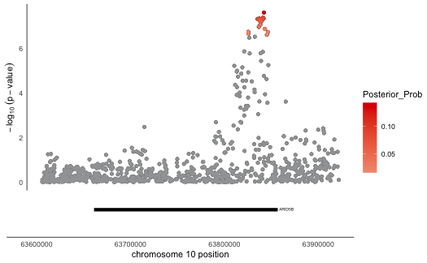

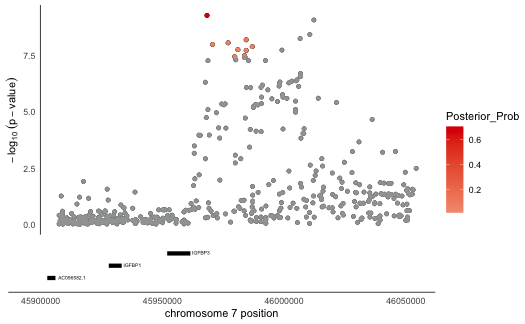

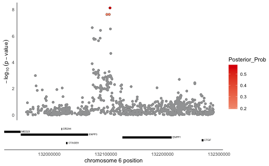

```r
RACER_loc = paste0(PROJECT_loc,"/RACER")

variants_of_interest <- c(add_list$rsID)


for(VARIANT in variants_of_interest){
  cat(paste0("Getting data for ", VARIANT,".\n"))

  tempCHR <- subset(add_list, rsID == VARIANT)[,4]
  tempSTART <- subset(add_list, rsID == VARIANT)[,5]
  tempEND <- subset(add_list, rsID == VARIANT)[,6]
  tempNAME <- subset(add_list, rsID == VARIANT)[,3]

  cat("\nSubset required data.\n")
  temp <- subset(gwas_sumstats_racer_credset, Chr == tempCHR & (Position >= tempSTART & Position <= tempEND))

  cat("\nFormatting association data.\n")
  temp_f = RACER::formatRACER(assoc_data = temp, chr_col = 3, pos_col = 4, p_col = 5)

  cat("\nGetting LD data.\n")
  # temp_f_ld = RACER::ldRACER(assoc_data = temp_f, rs_col = 2, pops = "EUR", lead_snp = VARIANT)

  cat(paste0("\nPlotting region surrounding ", VARIANT," on ",tempCHR,":",tempSTART,"-",tempEND,".\n"))

  p1 <- singlePlotRACER2(assoc_data = temp_f,
                         chr = tempCHR, build = "hg19",
                         plotby = "coord", snp_plot = VARIANT,
                         start_plot = tempSTART, end_plot = tempEND,
                         label_lead = FALSE,
                         grey_colors = FALSE,
                         cred_set = TRUE,
                         gene_track_h = 3, gene_name_s = 1.75)

  print(p1)

  cat(paste0("Saving image for ", VARIANT,".\n"))
  # ggsave(filename = paste0(RACER_loc, "/", tempNAME, ".", Today, ".",VARIANT,".",tempSTART,".",tempEND,".regional_assoc.png"), plot = p1)
  # ggsave(filename = paste0(RACER_loc, "/", tempNAME, ".", Today, ".",VARIANT,".",tempSTART,".",tempEND,".regional_assoc.pdf"), plot = p1)
  # ggsave(filename = paste0(RACER_loc, "/", tempNAME, ".", Today, ".",VARIANT,".",tempSTART,".",tempEND,".regional_assoc.eps"), plot = p1)

  # print(ggplotly(p1))
  rm(temp, p1,
     temp_f,
     tempCHR, tempSTART, tempEND,
     VARIANT, tempNAME)
}
```

## Regional association plots in African-American

Note here that we plot the region, and not based on the lead variant of the EA-AA analyses.

```r
library(RACER)
# Make directory for plots
ifelse(!dir.exists(file.path(PROJECT_loc, "/RACER_AA")),
       dir.create(file.path(PROJECT_loc, "/RACER_AA")),
       FALSE)
```

```
[1] FALSE
```

```
Getting data for rs9349379.

Subset required data.

Formatting association data.
```

```
Formating association data...
Processing -log10(p-values)...
Preparing association data...
```

```
Plotting region surrounding rs9349379 on 6:12403957-13403957.
```

```
Association Data Set is missing LD data, the resulting plot won't have LD information, but you can add it using the ldRACER.R function.
Plotting by...
coord
Reading in association data
Generating Plot
```

```
Saving image for rs9349379.
```

```
Warning in rm(temp, p1, temp_f, temp_f_ld, tempCHR, tempSTART, tempEND,  :
  object 'temp_f_ld' not found
```

```
Getting data for rs3844006.

Subset required data.

Formatting association data.
```

```
Formating association data...
Processing -log10(p-values)...
Preparing association data...
```

```
Plotting region surrounding rs3844006 on 6:131595002-132595002.
```

```
Association Data Set is missing LD data, the resulting plot won't have LD information, but you can add it using the ldRACER.R function.
Plotting by...
coord
Reading in association data
Generating Plot
```

```
Saving image for rs3844006.
```

```
Warning in rm(temp, p1, temp_f, temp_f_ld, tempCHR, tempSTART, tempEND,  :
  object 'temp_f_ld' not found
```

```
Getting data for rs2854746.

Subset required data.

Formatting association data.
```

```
Formating association data...
Processing -log10(p-values)...
Preparing association data...
```

```
Plotting region surrounding rs2854746 on 7:45460645-46460645.
```

```
Association Data Set is missing LD data, the resulting plot won't have LD information, but you can add it using the ldRACER.R function.
Plotting by...
coord
Reading in association data
Generating Plot
```

```
Saving image for rs2854746.
```

```
Warning in rm(temp, p1, temp_f, temp_f_ld, tempCHR, tempSTART, tempEND,  :
  object 'temp_f_ld' not found
```

```
Getting data for rs4977575.

Subset required data.

Formatting association data.
```

```
Formating association data...
Processing -log10(p-values)...
Preparing association data...
```

```
Plotting region surrounding rs4977575 on 9:21624744-22624744.
```

```
Association Data Set is missing LD data, the resulting plot won't have LD information, but you can add it using the ldRACER.R function.
Plotting by...
coord
Reading in association data
Generating Plot
```

```
Saving image for rs4977575.
```

```
Warning in rm(temp, p1, temp_f, temp_f_ld, tempCHR, tempSTART, tempEND,  :
  object 'temp_f_ld' not found
```

```
Getting data for rs10899970.

Subset required data.

Formatting association data.
```

```
Formating association data...
Processing -log10(p-values)...
Preparing association data...
```

```
Plotting region surrounding rs10899970 on 10:44015716-45334720.
```

```
Association Data Set is missing LD data, the resulting plot won't have LD information, but you can add it using the ldRACER.R function.
Plotting by...
coord
Reading in association data
Generating Plot
```

```
Saving image for rs10899970.
```

```
Warning in rm(temp, p1, temp_f, temp_f_ld, tempCHR, tempSTART, tempEND,  :
  object 'temp_f_ld' not found
```

```
Getting data for rs9633535.

Subset required data.

Formatting association data.
```

```
Formating association data...
Processing -log10(p-values)...
Preparing association data...
```

```
Plotting region surrounding rs9633535 on 10:63336088-64336088.
```

```
Association Data Set is missing LD data, the resulting plot won't have LD information, but you can add it using the ldRACER.R function.
Plotting by...
coord
Reading in association data
Generating Plot
```

```
Saving image for rs9633535.
```

```
Warning in rm(temp, p1, temp_f, temp_f_ld, tempCHR, tempSTART, tempEND,  :
  object 'temp_f_ld' not found
```

```
Getting data for rs10762577.

Subset required data.

Formatting association data.
```

```
Formating association data...
Processing -log10(p-values)...
Preparing association data...
```

```
Plotting region surrounding rs10762577 on 10:75417431-76417431.
```

```
Association Data Set is missing LD data, the resulting plot won't have LD information, but you can add it using the ldRACER.R function.
Plotting by...
coord
Reading in association data
Generating Plot
```

```
Saving image for rs10762577.
```

```
Warning in rm(temp, p1, temp_f, temp_f_ld, tempCHR, tempSTART, tempEND,  :
  object 'temp_f_ld' not found
```

```
Getting data for rs11063120.

Subset required data.

Formatting association data.
```

```
Formating association data...
Processing -log10(p-values)...
Preparing association data...
```

```
Plotting region surrounding rs11063120 on 12:3986618-4986618.
```

```
Association Data Set is missing LD data, the resulting plot won't have LD information, but you can add it using the ldRACER.R function.
Plotting by...
coord
Reading in association data
Generating Plot
```

```
Saving image for rs11063120.
```

```
Warning in rm(temp, p1, temp_f, temp_f_ld, tempCHR, tempSTART, tempEND,  :
  object 'temp_f_ld' not found
```

```
Getting data for rs9515203.

Subset required data.

Formatting association data.
```

```
Formating association data...
Processing -log10(p-values)...
Preparing association data...
```

```
Plotting region surrounding rs9515203 on 13:110549623-111549623.
```

```
Association Data Set is missing LD data, the resulting plot won't have LD information, but you can add it using the ldRACER.R function.
Plotting by...
coord
Reading in association data
Generating Plot
```

```
Saving image for rs9515203.
```

```
Warning in rm(temp, p1, temp_f, temp_f_ld, tempCHR, tempSTART, tempEND,  :
  object 'temp_f_ld' not found
```

```
Getting data for rs7182103.

Subset required data.

Formatting association data.
```

```
Formating association data...
Processing -log10(p-values)...
Preparing association data...
```

```
Plotting region surrounding rs7182103 on 15:78623946-79623946.
```

```
Association Data Set is missing LD data, the resulting plot won't have LD information, but you can add it using the ldRACER.R function.
Plotting by...
coord
Reading in association data
Generating Plot
```

```
Saving image for rs7182103.
```

```
Warning in rm(temp, p1, temp_f, temp_f_ld, tempCHR, tempSTART, tempEND,  :
  object 'temp_f_ld' not found
```

```
Getting data for rs7412.

Subset required data.

Formatting association data.
```

```
Formating association data...
Processing -log10(p-values)...
Preparing association data...
```

```
Plotting region surrounding rs7412 on 19:44912079-45912079.
```

```
Association Data Set is missing LD data, the resulting plot won't have LD information, but you can add it using the ldRACER.R function.
Plotting by...
coord
Reading in association data
Generating Plot
```

```
Saving image for rs7412.
```

```
Warning in rm(temp, p1, temp_f, temp_f_ld, tempCHR, tempSTART, tempEND,  :
  object 'temp_f_ld' not found
```

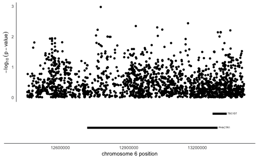

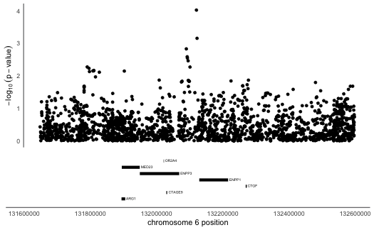

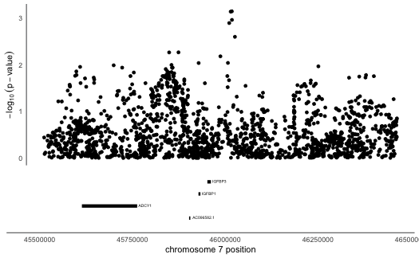

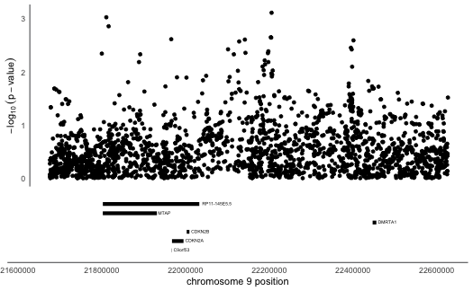

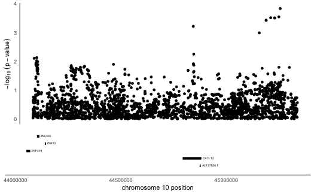

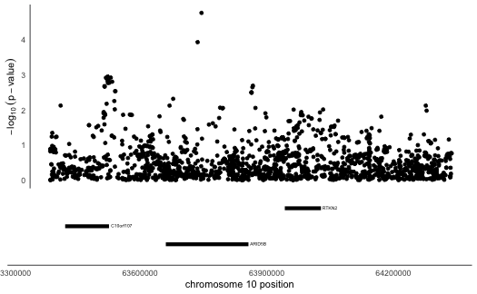

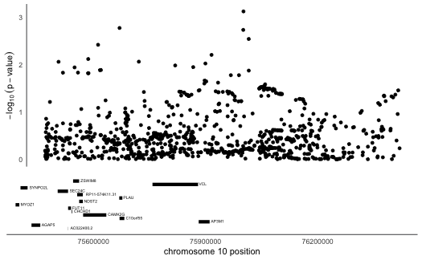

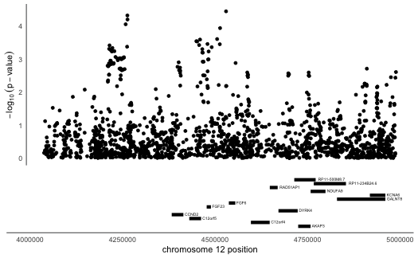

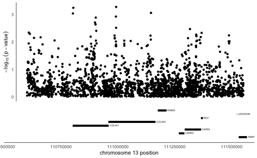

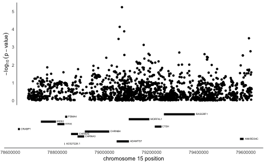

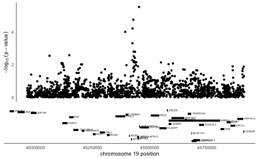

```r
RACER_AA_loc = paste0(PROJECT_loc,"/RACER_AA")

variants_of_interest <- c(variant_list$rsID)

variants_of_interest_fewgenes <- c("rs9349379",
                                   "rs3844006", # throws an error which I don't understand immediately - could be that the variant is not present in AA 1000G data
                                   "rs2854746", "rs4977575",
                                   "rs10899970",
                                   "rs9633535", # this one throws an LD error
                                   "rs10762577",
                                   "rs11063120", "rs9515203", "rs7182103",
                                   "rs7412")

for(VARIANT in variants_of_interest){
  cat(paste0("Getting data for ", VARIANT,".\n"))

  tempCHR <- subset(variant_list, rsID == VARIANT)[,5]
  tempSTART <- subset(variant_list, rsID == VARIANT)[,17]
  tempEND <- subset(variant_list, rsID == VARIANT)[,18]
  tempVARIANTnr <- subset(variant_list, rsID == VARIANT)[,1]

  cat("\nSubset required data.\n")
  temp <- subset(gwas_sumstats_racer_AA, Chr == tempCHR & (Position >= tempSTART & Position <= tempEND))

  cat("\nFormatting association data.\n")
  temp_f = RACER::formatRACER(assoc_data = temp, chr_col = 3, pos_col = 4, p_col = 5)

  # cat("\nGetting LD data.\n")
  #temp_f_ld = RACER::ldRACER(assoc_data = temp_f, rs_col = 2, pops = "AFR", lead_snp = VARIANT)

  cat(paste0("\nPlotting region surrounding ", VARIANT," on ",tempCHR,":",tempSTART,"-",tempEND,".\n"))

  p1 <- singlePlotRACER2(assoc_data = temp_f,
                         chr = tempCHR, build = "hg19",
                         plotby = "coord", snp_plot = VARIANT,
                         start_plot = tempSTART, end_plot = tempEND,
                         label_lead = FALSE, gene_track_h = 2, gene_name_s = 1.75)
   # p1 <- singlePlotRACER2(assoc_data = temp_f,
   #                       chr = tempCHR, build = "hg19",
   #                       plotby = "coord", snp_plot = VARIANT,
   #                       start_plot = tempSTART, end_plot = tempEND,
   #                       label_lead = FALSE,
   #                       grey_colors = FALSE,
   #                       cred_set = TRUE,
   #                       gene_track_h = 3, gene_name_s = 1.75)

  print(p1)
  cat(paste0("Saving image for ", VARIANT,".\n"))
  ggsave(filename = paste0(RACER_AA_loc, "/", tempVARIANTnr, ".", Today, ".",VARIANT,".regional_assoc.AA.png"), plot = last_plot())
  ggsave(filename = paste0(RACER_AA_loc, "/", tempVARIANTnr, ".", Today, ".",VARIANT,".regional_assoc.AA.pdf"), plot = last_plot())
  ggsave(filename = paste0(RACER_AA_loc, "/", tempVARIANTnr, ".", Today, ".",VARIANT,".regional_assoc.AA.eps"), plot = last_plot())

  rm(temp, p1,
     temp_f, temp_f_ld,
     tempCHR, tempSTART, tempEND,
     VARIANT, tempVARIANTnr)

}
```

```r
library(RACER)
# Make directory for plots
ifelse(!dir.exists(file.path(PROJECT_loc, "/RACER_EA_vs_AA")),
       dir.create(file.path(PROJECT_loc, "/RACER_EA_vs_AA")),
       FALSE)
```

```
[1] FALSE
```

```r
RACER_EA_vs_AA_loc = paste0(PROJECT_loc,"/RACER_EA_vs_AA")

variants_of_interest <- c(variant_list$rsID)

# variants_of_interest_fewgenes <- c("rs9349379",
#                                    "rs3844006", # throws an error which I don't understand immediately - could be that the variant is not present in AA 1000G data
#                                    "rs2854746", "rs4977575",
#                                    "rs10899970",
#                                    "rs9633535",
#                                    "rs10762577",
#                                    "rs11063120", "rs9515203", "rs7182103",
#                                    "rs7412")
variants_of_interest_fewgenes <- c("rs10762577",
                                   "rs11063120", "rs9515203", "rs7182103",
                                   "rs7412")
for(VARIANT in variants_of_interest){
  cat(paste0("Getting data for ", VARIANT,".\n"))

  tempCHR <- subset(variant_list, rsID == VARIANT)[,5]
  tempSTART <- subset(variant_list, rsID == VARIANT)[,17]
  tempEND <- subset(variant_list, rsID == VARIANT)[,18]
  tempVARIANTnr <- subset(variant_list, rsID == VARIANT)[,1]

  cat("\nSubset required data.\n")
  temp1 <- subset(gwas_sumstats_racer_EA, Chr == tempCHR & (Position >= tempSTART & Position <= tempEND))
  temp2 <- subset(gwas_sumstats_racer_AA, Chr == tempCHR & (Position >= tempSTART & Position <= tempEND))

  cat("\nFormatting association data.\n")
  temp_f1 = RACER::formatRACER(assoc_data = temp1, chr_col = 3, pos_col = 4, p_col = 5)
  temp_f2 = RACER::formatRACER(assoc_data = temp2, chr_col = 3, pos_col = 4, p_col = 5)

  # cat("\nGetting LD data.\n")
  temp_f_ld1 = RACER::ldRACER(assoc_data = temp_f1, rs_col = 2, pops = "EUR", lead_snp = VARIANT)
  temp_f_ld2 = RACER::ldRACER(assoc_data = temp_f2, rs_col = 2, pops = "AFR", lead_snp = VARIANT)

  cat(paste0("\nPlotting region surrounding ", VARIANT," on ",tempCHR,":",tempSTART,"-",tempEND,".\n"))

  p1 <- mirrorPlotRACER(assoc_data1 = temp_f_ld1,
                        assoc_data2 = temp_f_ld2,
                        chr = tempCHR,
                        name1 = "European ancestry",
                         name2 = "African-American ancestry",
                        plotby = "coord",
                        start_plot = tempSTART, end_plot = tempEND)

  print(p1)

  p2 <- scatterPlotRACER(assoc_data1 = temp_f_ld1,
                         assoc_data2 = temp_f_ld2,
                         chr = tempCHR,
                         name1 = "European ancestry",
                         name2 = "African-American ancestry",
                         region_start = tempSTART,
                         region_end = tempEND,
                         ld_df = 1)

  print(p2)

  cat(paste0("Saving image for ", VARIANT,".\n"))
  ggsave(filename = paste0(RACER_EA_vs_AA_loc, "/", tempVARIANTnr, ".", Today, ".",VARIANT,".regional_mirror.EA_vs_AA.png"), plot = p1)
  ggsave(filename = paste0(RACER_EA_vs_AA_loc, "/", tempVARIANTnr, ".", Today, ".",VARIANT,".regional_mirror.EA_vs_AA.pdf"), plot = p1)
  ggsave(filename = paste0(RACER_EA_vs_AA_loc, "/", tempVARIANTnr, ".", Today, ".",VARIANT,".regional_mirror.EA_vs_AA.eps"), plot = p1)

  cat(paste0("Saving image for ", VARIANT,".\n"))
  ggsave(filename = paste0(RACER_EA_vs_AA_loc, "/", tempVARIANTnr, ".", Today, ".",VARIANT,".regional_scatter.EA_vs_AA.png"), plot = p2)
  ggsave(filename = paste0(RACER_EA_vs_AA_loc, "/", tempVARIANTnr, ".", Today, ".",VARIANT,".regional_scatter.EA_vs_AA.pdf"), plot = p2)
  ggsave(filename = paste0(RACER_EA_vs_AA_loc, "/", tempVARIANTnr, ".", Today, ".",VARIANT,".regional_scatter.EA_vs_AA.eps"), plot = p2)


  rm(temp1, temp2,
     p1,p2,
     temp_f1, temp_f_ld1,
     temp_f2, temp_f_ld2,
     tempCHR, tempSTART, tempEND,
     VARIANT, tempVARIANTnr)

}
```

[output not shown]

```
Getting data for rs9349379.

Subset required data.

Formatting association data.
```

```
Formating association data...
Processing -log10(p-values)...
Preparing association data...
Formating association data...
Processing -log10(p-values)...
Preparing association data...
All inputs are go!
Reading in association data...
Populations selected.
Calculating LD using rs9349379...
```

```
[1] "https://ldlink.nci.nih.gov/LDlinkRest/ldproxy?var=rs9349379&pop=EUR&r2_d=r2&token=c0f613f149ab"
```

```
 [45%] Downloaded 32210 bytes...
 [69%] Downloaded 49152 bytes...
 [100%] Downloaded 70967 bytes...
Merging input association data with LD...
All inputs are go!
Reading in association data...
Populations selected.
Calculating LD using rs9349379...
```

```
[1] "https://ldlink.nci.nih.gov/LDlinkRest/ldproxy?var=rs9349379&pop=AFR&r2_d=r2&token=c0f613f149ab"
```

```
 [33%] Downloaded 32210 bytes...
 [50%] Downloaded 48576 bytes...
 [57%] Downloaded 55496 bytes...
 [100%] Downloaded 95751 bytes...
Merging input association data with LD...
```

```
Plotting region surrounding rs9349379 on 6:12403957-13403957.
```

```
Plotting by...
coord
Reading in association data
Generating plot.
Reading in association data
Generating plot.
```

```
Saving image for rs9349379.
```

```
Saving image for rs9349379.
```

```
Getting data for rs3844006.

Subset required data.

Formatting association data.
```

```
Formating association data...
Processing -log10(p-values)...
Preparing association data...
Formating association data...
Processing -log10(p-values)...
Preparing association data...
All inputs are go!
Reading in association data...
Populations selected.
Calculating LD using rs3844006...
```

```
[1] "https://ldlink.nci.nih.gov/LDlinkRest/ldproxy?var=rs3844006&pop=EUR&r2_d=r2&token=c0f613f149ab"
```

```
 [100%] Downloaded 31016 bytes...
Merging input association data with LD...
All inputs are go!
Reading in association data...
Populations selected.
Calculating LD using rs3844006...
```

```
[1] "https://ldlink.nci.nih.gov/LDlinkRest/ldproxy?var=rs3844006&pop=AFR&r2_d=r2&token=c0f613f149ab"
```

```
 [76%] Downloaded 55496 bytes...
 [100%] Downloaded 72560 bytes...
Merging input association data with LD...
```

```
Plotting region surrounding rs3844006 on 6:131595002-132595002.
```

```
Plotting by...
coord
Reading in association data
Generating plot.
Reading in association data
Generating plot.
```

```
Saving image for rs3844006.
```

```
Saving image for rs3844006.
```

```
Getting data for rs2854746.

Subset required data.

Formatting association data.
```

```
Formating association data...
Processing -log10(p-values)...
Preparing association data...
Formating association data...
Processing -log10(p-values)...
Preparing association data...
All inputs are go!
Reading in association data...
Populations selected.
Calculating LD using rs2854746...
```

```
[1] "https://ldlink.nci.nih.gov/LDlinkRest/ldproxy?var=rs2854746&pop=EUR&r2_d=r2&token=c0f613f149ab"
```

```
 [44%] Downloaded 49152 bytes...
 [74%] Downloaded 81920 bytes...
 [89%] Downloaded 98286 bytes...
 [100%] Downloaded 109298 bytes...
Merging input association data with LD...
All inputs are go!
Reading in association data...
Populations selected.
Calculating LD using rs2854746...
```

```
[1] "https://ldlink.nci.nih.gov/LDlinkRest/ldproxy?var=rs2854746&pop=AFR&r2_d=r2&token=c0f613f149ab"
```

```
 [77%] Downloaded 55496 bytes...
 [100%] Downloaded 71651 bytes...
Merging input association data with LD...
```

```
Plotting region surrounding rs2854746 on 7:45460645-46460645.
```

```
Plotting by...
coord
Reading in association data
Generating plot.
Reading in association data
Generating plot.
```

```
Saving image for rs2854746.
```

```
Saving image for rs2854746.
```

```
Getting data for rs4977575.

Subset required data.

Formatting association data.
```

```
Formating association data...
Processing -log10(p-values)...
Preparing association data...
Formating association data...
Processing -log10(p-values)...
Preparing association data...
All inputs are go!
Reading in association data...
Populations selected.
Calculating LD using rs4977575...
```

```
[1] "https://ldlink.nci.nih.gov/LDlinkRest/ldproxy?var=rs4977575&pop=EUR&r2_d=r2&token=c0f613f149ab"
```

```
 [100%] Downloaded 26000 bytes...
Merging input association data with LD...
All inputs are go!
Reading in association data...
Populations selected.
Calculating LD using rs4977575...
```

```
[1] "https://ldlink.nci.nih.gov/LDlinkRest/ldproxy?var=rs4977575&pop=AFR&r2_d=r2&token=c0f613f149ab"
```

```
 [34%] Downloaded 32210 bytes...
 [59%] Downloaded 55496 bytes...
 [77%] Downloaded 71862 bytes...
 [94%] Downloaded 88264 bytes...
 [100%] Downloaded 93249 bytes...
Merging input association data with LD...
```

```
Plotting region surrounding rs4977575 on 9:21624744-22624744.
```

```
Plotting by...
coord
Reading in association data
Generating plot.
Reading in association data
Generating plot.
```

```
Saving image for rs4977575.
```

```
Saving image for rs4977575.
```

```
Getting data for rs10899970.

Subset required data.

Formatting association data.
```

```
Formating association data...
Processing -log10(p-values)...
Preparing association data...
Formating association data...
Processing -log10(p-values)...
Preparing association data...
All inputs are go!
Reading in association data...
Populations selected.
Calculating LD using rs10899970...
```

```
[1] "https://ldlink.nci.nih.gov/LDlinkRest/ldproxy?var=rs10899970&pop=EUR&r2_d=r2&token=c0f613f149ab"
```

# Session information

```
Version:      v1.4.0
Last update:  2022-06-27
Written by:   Sander W. van der Laan (s.w.vanderlaan-2[at]umcutrecht.nl).
Description:  Script to create plot regional association plots.
Minimum requirements: R version 3.4.3 (2017-06-30) -- 'Single Candle', Mac OS X El Capitan

Changes log
* v1.4.0 Update with AA data.
* v1.3.0 Added the credible sets to the aditional regions.
* v1.2.0 Added in aditional regions.
* v1.1.0 Created PNG and PDF of top loci regions.
* v1.0.0 Initial version.
```

# Saving environment

```r
save.image(paste0(PROJECT_loc, "/",Today,".",PROJECTNAME,".RegionalAssociationPlots.RData"))
```

| <sup>© 1979-2022 Sander W. van der Laan \| s.w.vanderlaan[at]gmail.com \| swvanderlaan.github.io.</sup> |
| --- |